# 03-Cleaned Burning Glass Data Profiling

# Data Profiling on Joined Burning Galss Data

## 1. demographic, education of all individuals in bgt

620007 people are found in the DC metropolitan area, and there are 7704 (1.24%) veterans in DC metropolitan area included in our analysis.

```r
bg_demographic <- bg_full_cleaned%>%
  select(id, gender, veteran, degree_highest)
bg_demographic <- bg_demographic[!duplicated(bg_demographic$id), ]
nrow(bg_demographic)
```

```
## [1] 620007
```

```r
table(bg_demographic$veteran)
```

```
##
## not veteran     veteran
##      612303        7704
```

```r
bg_demographic%>%
  data_profiling()%>%
  gt()%>%
  tab_header(
    title ="data profiling on demographic and education variables among all individuals"
  )
```

data profiling on demographic and education variables among all individuals

| var | variable_type | num_unique | num_missing | perc_missing |
| --- | --- | --- | --- | --- |
| id | integer | 620007 | 0 | 0.00 |
| gender | character | 3 | 108329 | 17.47 |
| veteran | character | 2 | 0 | 0.00 |
| degree_highest | character | 9 | 331404 | 53.45 |

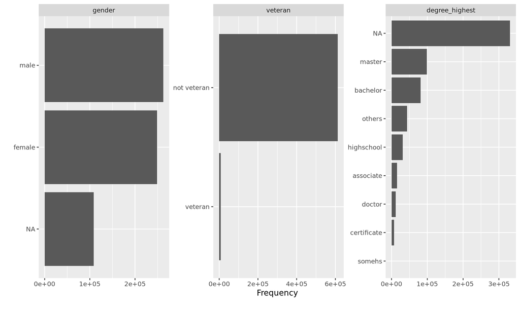

```r
plot_bar(bg_demographic)
```

## 2. demographic, education of veterans

```r
bg_vet_demographic <- bg_full_cleaned%>%
  filter(veteran == "veteran")%>%
  select(id, gender, degree_highest)
bg_vet_demographic <- bg_vet_demographic[!duplicated(bg_vet_demographic$id), ]

bg_vet_demographic%>%
  data_profiling()%>%
  gt()%>%
  tab_header(
    title ="data profiling on demographic and education variables among veterans"
  )
```

data profiling on demographic and education variables among veterans

| var | variable_type | num_unique | num_missing | perc_missing |
| --- | --- | --- | --- | --- |
| id | integer | 7704 | 0 | 0.00 |
| gender | character | 3 | 1040 | 13.50 |
| degree_highest | character | 8 | 3398 | 44.11 |

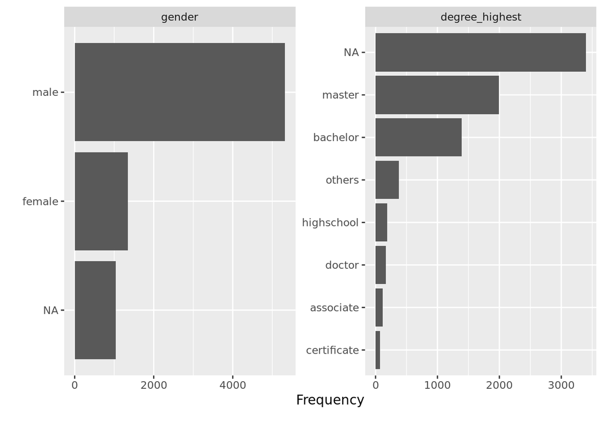

```r
plot_bar(bg_vet_demographic)
```